# Week 9 - Practice

Viki - Misi

17 November 2022

## Dataset

The [birthweight](https://rdrr.io/cran/MASS/man/birthwt.html) data from the **MASS** package was collected at Baystate Medical Center, Springfield, Mass during 1986. The data set contains risk factors associated with low infant birth weight. We will look at how the mothers actions (whether the mother smoked during pregnancy) and health during pregnancy affects the birth weight of a baby.

```r
library(MASS)

data(birthwt, package = "MASS")
head(birthwt)
```

```
##    low age lwt race smoke ptl ht ui ftv  bwt
## 85   0  19 182    2     0   0  0  1   0 2523
## 86   0  33 155    3     0   0  0  0   3 2551
## 87   0  20 105    1     1   0  0  0   1 2557
## 88   0  21 108    1     1   0  0  1   2 2594
## 89   0  18 107    1     1   0  0  1   0 2600
## 91   0  21 124    3     0   0  0  0   0 2622
```

**Variables**:

- bwt: birth weight in grams. - **Outcome**
- smoke: smoking status during pregnancy.
- race: mother’s race (1 = white, 2 = black, 3 = other).
- age: mother’s age in years.
- lwt: mother’s weight in pounds at last menstrual period.
- ptl: number of previous premature labours.
- ht: history of hypertension.
- ui: presence of uterine irritability.
- ftv: number of physician visits during the first trimester.

## Data preparation

Convert the categorical variables into factors!

```
##    low age lwt             race      smoke ptl ht  ui ftv  bwt
## 85   0  19 182 African American Non-smoker   0 No Yes   0 2523
## 86   0  33 155            Other Non-smoker   0 No  No   3 2551
## 87   0  20 105            White     Smoker   0 No  No   1 2557
## 88   0  21 108            White     Smoker   0 No Yes   2 2594
## 89   0  18 107            White     Smoker   0 No Yes   0 2600
## 91   0  21 124            Other Non-smoker   0 No  No   0 2622
```

## Compare averages (Unconditional means)

Create a summary table of the babies’ birth weight by *smoke*. Use the **modelsummary** package.

Descriptive statistics

| Smoking |  | N | Mean | SD | Min | Max | P05 | Median | P95 |
| --- | --- | --- | --- | --- | --- | --- | --- | --- | --- |
| Non-smoker | Birth weight | 115 | 3055.70 | 752.66 | 1021 | 4990 | 1720.60 | 3100.00 | 4071.10 |
| Smoker | Birth weight | 74 | 2771.92 | 659.63 | 709 | 4238 | 1861.55 | 2775.50 | 3791.00 |

Source: MASS package

## Compare averages (Conditional means)

Create a summary table of the babies’ birth weight by *smoke* and *race*.

Descriptive statistics

| Smoking | Race |  | N | Mean | SD | Min | Max | P05 | Median | P95 |
| --- | --- | --- | --- | --- | --- | --- | --- | --- | --- | --- |
| Non-smoker | White | Birth weight | 44 | 3428.75 | 710.10 | 1021 | 4990 | 2137.95 | 3593.00 | 4172.95 |
|  | African American | Birth weight | 16 | 2854.50 | 621.25 | 1701 | 3860 | 1871.25 | 2920.00 | 3807.50 |
|  | Other | Birth weight | 55 | 2815.78 | 709.35 | 1330 | 4054 | 1588.00 | 2807.00 | 3949.40 |
| Smoker | White | Birth weight | 52 | 2826.85 | 626.47 | 1790 | 4238 | 1908.65 | 2775.50 | 3868.60 |
|  | African American | Birth weight | 10 | 2504.00 | 637.06 | 1135 | 3444 | 1580.95 | 2381.00 | 3263.10 |
|  | Other | Birth weight | 12 | 2757.17 | 810.04 | 709 | 3572 | 1487.80 | 3146.50 | 3439.45 |

Source: MASS package

Visualize the results!

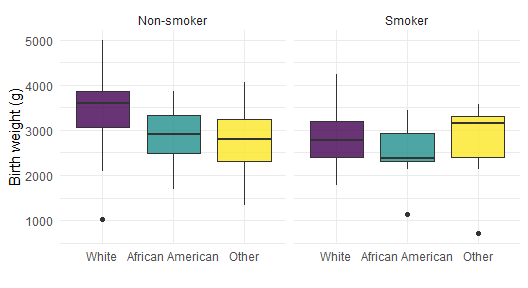

## Packages for linear regression - Summary

Regressions

| Model | Code | Dependency |
| --- | --- | --- |
| Model 1 | summary(lm(bwt ~ smoke + race, data = birthwt), vcov = sandwich) | sandwich |
| Model 2 | lm_robust(bwt ~ smoke + race, data = birthwt, se_type = ‘HC1’) | estimatr |
| Model 3 | feols(bwt ~ smoke + race ,data = birthwt, vcov = ‘hetero’) | fixest |

## Regression analysis

- Regress the birth weight of the babies on **smoke**, on **smoke** and **race** and extend the regressions with the rest of the predictors!
- Save the results of your regressions as reg1, reg2 etc.
- Use the [fixest](https://www.rdocumentation.org/packages/fixest/versions/0.8.4/topics/feols) package for the regressions and the [modelsummary](https://vincentarelbundock.github.io/modelsummary/articles/modelsummary.html) package to create the regression table!

Dependent variable: Birth weight

Intercept

3055.696***

3334.947***

3281.673***

2839.433***

2841.299***

2927.962***

(70.252)

(95.622)

(293.226)

(331.841)

(337.485)

(325.301)

Smoker

-283.777**

-428.730***

-426.093***

-401.720***

-401.345***

-352.045**

(103.913)

(112.007)

(112.637)

(113.321)

(112.760)

(105.786)

Race: African-AMerican

-450.359**

-444.069**

-510.501***

-510.344***

-488.428***

(139.883)

(146.878)

(144.917)

(145.096)

(128.795)

Race: Other

-452.876***

-447.858***

-398.644**

-397.954**

-355.077**

(124.611)

(128.574)

(128.539)

(127.238)

(119.125)

Mother’s age

2.134

-1.948

-2.122

-3.570

(11.417)

(12.050)

(12.594)

(12.273)

Mother’s weight

4.000**

3.985**

4.354**

(1.518)

(1.528)

(1.616)

Number of physician visits

4.647

-14.058

(43.406)

(41.177)

Number of previous premature labours

-48.402

(125.314)

History of hypertension

-592.827**

(212.806)

Presence of uterine irritability

-516.081***

(153.176)

Num.Obs.

189

189

189

189

189

189

R2

0.036

0.123

0.124

0.148

0.148

0.243

R2 Adj.

0.031

0.109

0.105

0.125

0.120

0.205

# Confidence intervals

- Extract the coefficients, standard errors and confidence intervals of the *smoke* parameter
- Create a summary table with the **smoke** coefficients, standard errors and confidence intervals from the 6 regressions
- Visualize the results

Coefficients and CIs

| Model | Coefficient | SE | CI_lower | CI_uppper |
| --- | --- | --- | --- | --- |
| Model1 | -283.7767 | 103.9132 | -488.7696 | -78.78385 |
| Model2 | -428.7297 | 112.0067 | -649.7044 | -207.75496 |
| Model3 | -426.0933 | 112.6368 | -648.3190 | -203.86769 |
| Model4 | -401.7205 | 113.3207 | -625.3036 | -178.13742 |
| Model5 | -401.3445 | 112.7595 | -623.8285 | -178.86056 |
| Model6 | -352.0445 | 105.7858 | -560.7923 | -143.29675 |

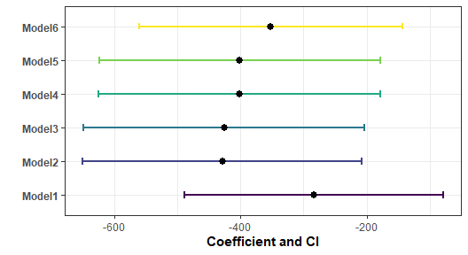